# More on Linear Regression

Lecture 06

February 4, 2026

# Review

## Linear Regression

The “simplest” model is **linear**:

1. The distribution of $X$ is arbitrary.
2. If $X = \mathbf{x}, Y = \sum_{i=1}^n \beta_i x_i + \varepsilon$.
3. $\mathbf{E}[\varepsilon | X = x] = 0, \text{Var}[\varepsilon | X = x] = \sigma^2$.
4. $\varepsilon$ is uncorrelated across observations.

## Ordinary Least Squares

Fit model by minimizing MSE:

$$\begin{aligned}
\hat{\beta}_0 &= \bar{y} - \hat{\beta}_1 \bar{x} \\
\hat{\beta}_1 &= \text{Cov}(X,Y) / \text{Var}(X) \\
\hat{\sigma}^2 &= \frac{1}{n-2}\sum_{i=1}^n \left(y_i - \hat{m}(x)\right)^2
\end{aligned}$$

# Properties of OLS Solutions

## Conditional Bias of Estimator: $\hat{\beta}_1$

An estimator $\hat{\beta}$ of parameter $\beta$ is **unbiased** if $\mathbb{E}[\hat{\beta}] = \beta$.

With some algebra (replace $\text{Cov}(X,Y) = \bar{xy} - \bar{x}\bar{y}$ and use the linear model), can rewrite $\hat{\beta}_1$ as:

$$\hat{\beta}_1 = \beta_1 + \frac{\frac{1}{n}\sum_{i=1}^n x_i \varepsilon_i - \bar{x}\bar{\varepsilon}}{\text{Var(X)}}.$$

## Conditional Bias of Estimator: $\hat{\beta}_1$

Since $\mathbb{E}\left[\varepsilon_i | X = \mathbf{x}\right] = 0$,

$$\mathbf{E}\left[\hat{\beta}_1 | X = \mathbf{x}\right] = \beta_1.$$

## Conditional Bias of Estimator: $\hat{\beta}_0$

$$\begin{aligned}
\mathbb{E}\left[\hat{\beta}_0 | X = \mathbf{x}\right] &= \mathbb{E}\left[\bar{y} - \hat{\beta}_1\bar{x}\right] \\
&= \beta_0 + \beta_1 \bar{x} - \mathbb{E}\left[\hat{\beta}_1\right] \bar{x} \\
&= \beta_0 + \beta_1 \bar{x} - \beta_1 \bar{x} \\
&= \beta_0.
\end{aligned}$$

## Unconditional Bias

It turns out these estimators are also unbiased unconditionally as a result of the **law of total expectation**.

For example:

$$\begin{aligned}
\mathbb{E}\left[\hat{\beta}_1\right] &= \mathbb{E}_X\left[\mathbb{E}\left[\hat{\beta}_1 | X = \mathbf{x}\right]\right] \\
&= \mathbb{E}\left[\hat{\beta}_1\right] = \beta_1.
\end{aligned}$$

## Interpretation of Parameters

- People often interpret $\hat{\beta}_1$ as the “effect” of changing $x$ by a unit amount.
- **Can we think of why this is wrong**?
- Safer interpretation: $\hat{\beta}_1$ is the expected **difference** if the predictors differ by 1.

[figure not shown]

Causation Meme

Source: Richard McElreath

## Properties of OLS Solution

The OLS solution always exists unless $\text{Var}(X) = 0$. This doesn’t mean it’s good if the model is wrong!

**Pernicious**: In this case, the fit depends on the distribution of the data.

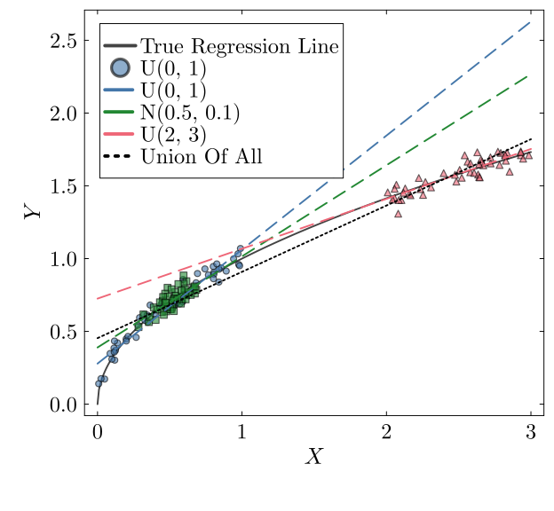

```julia
X1 = rand(Uniform(0, 1), 50)
X2 = rand(Normal(0.5, 0.1), 50)
X3 = rand(Uniform(2, 3), 50)
Xall = [X1; X2; X3]
Y1 = sqrt.(X1) .+ rand(Normal(0, 0.05), 50)
Y2 = sqrt.(X2) .+ rand(Normal(0, 0.05), 50)
Y3 = sqrt.(X3) .+ rand(Normal(0, 0.05), 50)
Yall = [Y1; Y2; Y3]

# set range for prediction/plotting
Xpred = 0:0.01:3

# use GLM.jl to fit the regressions just to clean things up
# this uses MLE but as we will see is equivalent to OLS for linear models
lm1 = lm([ones(length(X1)) X1], Y1)
pred1 = predict(lm1, [ones(length(Xpred)) Xpred])
lm2 = lm([ones(length(X2)) X2], Y2)
pred2 = predict(lm2, [ones(length(Xpred)) Xpred])
lm3 = lm([ones(length(X3)) X3], Y3)
pred3 = predict(lm3, [ones(length(Xpred)) Xpred])
lmall = lm([ones(length(Xall)) Xall], Yall)
predall = predict(lmall, [ones(length(Xpred)) Xpred])

# plot true regression line, data points, and OLS predictions
p_demo = plot(Xpred, sqrt.(Xpred), color="#444444", linewidth=2, label="True Regression Line")
scatter!(X1, Y1, color="#4477AA", markershape=:circle, markersize=4, alpha=0.6, label="U(0, 1)")
scatter!(X2, Y2, color="#228833", markershape=:square, markersize=4, alpha=0.6, label=false)
scatter!(X3, Y3, color="#EE6677", markershape=:utriangle, markersize=4, alpha=0.6, label=false)
plot!(Xpred, pred1, color="#4477AA", linewidth=2, linestyle=:dash, label="U(0, 1)")
plot!(Xpred, pred2, color="#228833", linewidth=2, linestyle=:dash, label="N(0.5, 0.1)")
plot!(Xpred, pred3, color="#EE6677", linewidth=2, linestyle=:dash, label="U(2, 3)")
plot!(Xpred, predall, color=:black, linewidth=2, linestyle=:dot, label="Union Of All")
xlabel!(L"$X$")
ylabel!(L"$Y$")
plot!(size=(650, 600))
```

## $R^2$

$$R^2 = \frac{s^2_\hat{m}}{s^2_Y}$$

- Extemely common metric due to ease of computing.
- **Common claim**: This represents “goodness of fit” or “amount of variance explained by the model.”

## $R^2$: Alternative Defintions

**For linear models estimated through least squares**:
$$\begin{aligned}
R^2 &= \frac{s^2_{\hat{m}}}{s^2_Y} = \frac{c_{Y, \hat{m}}}{s^2_Y} = \hat{\beta}_1^2\frac{s_X^2}{s_Y^2} \\
&= \left(\frac{c_{X,Y}}{s_Xs_Y}\right)^2 \\
&= \frac{s_Y^2 - \hat{\sigma}^2}{s_Y^2}
\end{aligned}$$

## Why $R^2$ is A Distraction

1. It doesn’t measure goodness of fit!

## Why $R^2$ is A Distraction

If we knew the “true” regression slope $\beta_1$, not hard to derive
$$R^2 = \frac{\beta_1^2 \text{Var}(X)}{\beta_1^2 \text{Var}(X) + \sigma^2}.$$

This can be made arbitrarily small if $\text{Var}(X)$ is small or $\sigma^2$ is large **even if the model is true**. And when the model is wrong, $R^2$ can be made arbitrarily large. As a result, $R^2$ is **not a stable property**.

## Why $R^2$ is A Distraction

For example, in our previous simulation:

- the blue line has $R^2 = 0.92$,
- the green line has $R^2=0.66$,
- the red line has $R^2 = 0.83$,
- and the black line $R^2=0.96$.

We could get very high $R^2$ even for fits that are not great anywhere!

## Why $R^2$ is A Distraction

2. It says nothing about prediction error (changing $\Var(X)$ can change everything about $R^2$).
3. Cannot be compared across different datasets (since it’s impacted by $\text{Var}(x)$).
4. Is not preserved under transformations.
5. It doesn’t **explain** anything about variance: $x$ regressed on $y$ gives the same $R^2$ as $y$ regressed on $x$.

# Prediction

## Predicting Values

We don’t know the “true” $\beta_0$ and $\beta_1$, just our estimates $\hat{\beta}_0$ and $\hat{\beta}_1$.

At an arbitrary value of $x$, we predict a value $\hat{m}(x) = \hat{\beta}_0 + \hat{\beta}_1 x.$

$\hat{m}(x)$ is an **estimate** of $\mathbb{E}[Y | X = x]$ under the assumption of the model and our estimate (which is a random variable).

## Linear Predictions Are Biased Conditionally

While the linear predictor has no bias (averaged over all $X$), $\mathbb{E}[Y - X \hat{\beta}] = 0$…

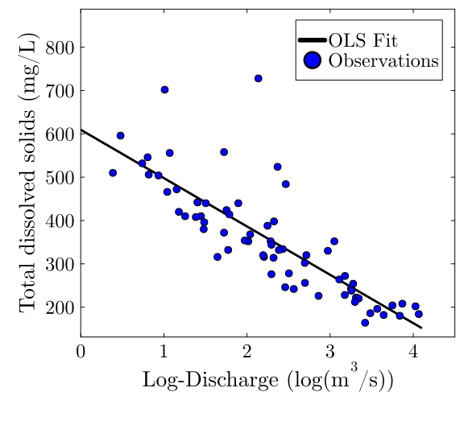

Figure 1: Linear regression fit to the TDS data.

```julia
tds = let
    fname = "data/tds/cuyaTDS.csv" # CHANGE THIS!
    tds = DataFrame(CSV.File(fname))
    tds[!, [:date, :discharge_cms, :tds_mgL]]
end
X = log.(tds.discharge_cms) # predictors
Y = tds.tds_mgL # predicands
β = zeros(2)
β[2] = cov(X, Y) / var(X)
β[1] = mean(Y) - β[2] * mean(X)
ε = Y - [ones(length(X)) X] * β
s² = (ε' * ε) / (nrow(tds) - 2)  # error estimate

# get predictions
x_pred = log.(0.1:0.1:60)
y_pred = β[1] .+ β[2] * x_pred
plot(x_pred, y_pred, label="OLS Fit", color=:black, linewidth=3,
    xlabel=L"Log-Discharge (log(m$^3$/s))",
    ylabel="Total dissolved solids (mg/L)",
    size=(600, 550),
    xlims = (0, 4.5))
scatter!(
    log.(tds.discharge_cms),
    tds.tds_mgL,
    markersize=5,
    label="Observations", color=:blue
)
```

## What If The Model Is Wrong?

And as noted, if the model is wrong, none of this is true anyway: the model will be biased and so will its predictions.

[figure not shown]

Brain on Regression meme

Source: Richard McElreath

# Multiple Linear Regression

## OLS for Multiple Linear Regression

To generalize to multiple predictors: let $\mathbf{x}$ be the $n \times p$ matrix of predictors and $\mathbf{y} = \sum_{i=1}^n \beta_i x_i.$

## OLS for Multiple Linear Regression

If the columns of $X$ are linearly independent, then the unique solution to minimizing least squares:
$$\hat{\mathbf{\beta}} = \left(X^TX\right)^{-1}X^TY$$

## Multiple Regression Error Variance

To get an estimate of the error variance $\hat{\sigma}^2$:

$$\hat{\sigma}^2 = \frac{(Y-X\hat{\beta})^T(Y-X\hat{\beta})}{n-p},$$

where $n$ is the number of data points and $p$ is the number of terms.

## Linear Algebra Model Fitting Example

For our River Flow-TDS example:

```julia
X = [ones(nrow(tds)) log.(tds.discharge_cms)] # predictors
Y = tds.tds_mgL # predicands
β = inv(X' * X) * X' * Y # OLS formula
@show β;
ε = Y - X * β
s² = (ε' * ε) / (nrow(tds) - 2)  # error estimate
@show s²;
```

```
β = [609.5487272461871, -111.63106902057211]
s² = 5266.230284046526
```

## Interpretation of Predictors

Multiple linear regression assumes each predictor variable makes a **separate, additive, and linear** contribution to the expected response.

So $\beta_i$ is the rate at which $Y$ changes if **only** $X_i$ changes.

## Multiple Regression Is Not Many Simple Regressions

In general, you **will not** get the same coefficients for a multiple regression that you get if you treat each predictor individually.

**Why not**?

## Multiple Regression Is Not Many Simple Regressions

Intuitively: in a simple regression of $Y$ on $X_1$, the predicted difference of $Y$ with respect to a change in $X_1$ combines

1. the **direct** contribution of $X_1$ to $Y$
2. the indirect contributions of $X_1$ through the other predictors $X_{i \neq 1}$.

This also illustrates the danger of **omitted variable bias**.

## Interpreting Predictors or Predictions?

- I generally find it less useful to try to interpret predictors, since these only make sense in the context of the included predictors.
- Better to interpret predictions or varying summary statistics instead (“effect sizes”).

## Collinearity

$$\hat{\mathbf{\beta}} = \left(X^TX\right)^{-1}X^TY$$

What happens if some predictors are linear combinations of the others?

$X^TX$ is not invertible, so there is no unique solution.

This doesn’t matter for **prediction** (you get the same value) but does for inference: you can only identify the total contribution $\beta_i x_i + \beta_j x_j$.

# Key Points

## OLS Estimates

- **If the linear model is true**, OLS gives unbiased parameter estimates and (unconditionally) unbiased predictions.
- **Linear regression is often treated as magic**. It is not: estimates are sensitive to data distributions and included variables.

## Interpeting OLS Estimates

- Coefficients are best interpreted as **differences in responses given a unit change in a single predictor**.
- They only reflect correlations (direct + indirect), not causation.
- Try to interpret effect sizes, not coefficients (more on this when we talk about hypothesis testing).

# Upcoming Schedule

## Next Classes

**Friday**: LR As a Probability Model; Maximum Likelihood Estimation

## Assessments

**Homework 1** Due Friday, 2/6.

**Exercises**: Due before class Monday.

**Reading**: Shmueli (2010).

**Quiz 1**: Next Friday (2/13). Will include Monday’s content.

# References